# Plotting and exporting

tidymatrix does not have its own plotting system. Instead it makes it easy to get the data into the shape that plotting packages expect:

- the **metadata** (with PC scores, cluster labels, test results, …) is a data frame, ready for ggplot2;
- `to_long()` gives **one row per matrix cell** with all metadata attached, for plots of the individual values;
- `plot_pheatmap()` draws a **heatmap** of the matrix with the metadata as annotations.

The same tools get the data out of R, which is covered at the end.

```r
library(tidymatrix)
library(dplyr, warn.conflicts = FALSE)
```

```r
library(ggplot2)
theme_set(theme_minimal())
```

## Data

We use the `big5` personality survey (see `?big5`): careless respondents removed, reverse-keyed items re-scored, and a score per trait added to the respondent metadata. The Matrix operations and Row- and column-wise statistics vignettes explain these steps.

```r
tm <- tidymatrix(big5_responses, big5_respondents, big5_items) |>
  activate(rows) |>
  filter(completion_min > 3.5) |>
  transform_matrix(\(x, flip) ifelse(flip, 6L - x, x), flip = reversed) |>
  compute_across(
    \(answers, items) tapply(answers, items$trait, mean),
    add_to_data = TRUE,
    prefix = "score"
  ) |>
  mutate(age_group = cut(
    age,
    breaks = c(17, 29, 49, 64, Inf),
    labels = c("18-29", "30-49", "50-64", "65+")
  )) |>
  compute_prcomp(n_components = 2, store = FALSE) |>
  activate(columns) |>
  compute_prcomp(n_components = 2, store = FALSE)
```

The two `compute_prcomp()` calls add principal component scores to the respondent and item metadata. `store = FALSE` skips storing the full `prcomp` objects, which we do not need here.

## Plotting metadata

### PCA of respondents

After `compute_prcomp()`, the PC scores are columns of the row metadata. Plot them with `as_tibble()` and ggplot2, and colour by any other variable:

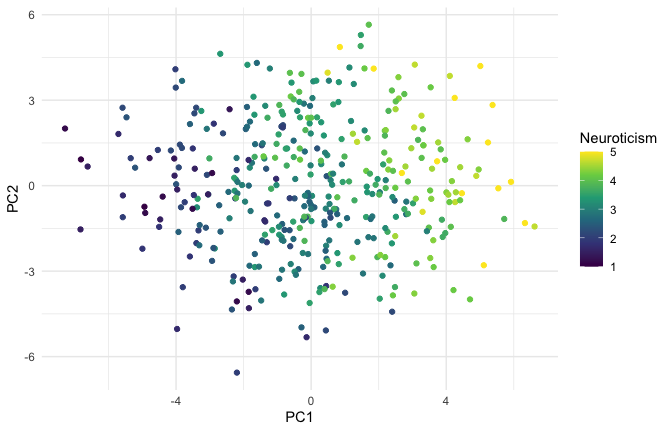

```r
tm |>
  activate(rows) |>
  as_tibble() |>
  ggplot(aes(row_pca_PC1, row_pca_PC2, colour = score_Neuroticism)) +
  geom_point() +
  scale_colour_viridis_c() +
  labs(x = "PC1", y = "PC2", colour = "Neuroticism")
```

### PCA of items

With columns active, items become points. Labelling them with their IDs shows that items of the same trait group together:

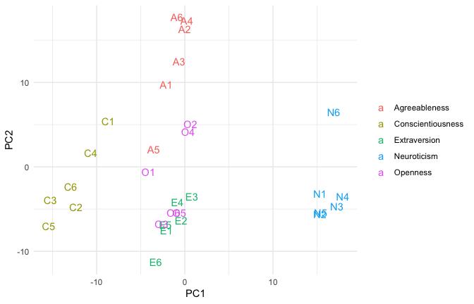

```r
tm |>
  activate(columns) |>
  as_tibble() |>
  ggplot(aes(column_pca_PC1, column_pca_PC2, colour = trait)) +
  geom_text(aes(label = item_id)) +
  labs(x = "PC1", y = "PC2", colour = NULL)
```

### Relationships between metadata variables

Trait scores computed from the matrix sit next to the demographics, so their relationship is a regular scatterplot:

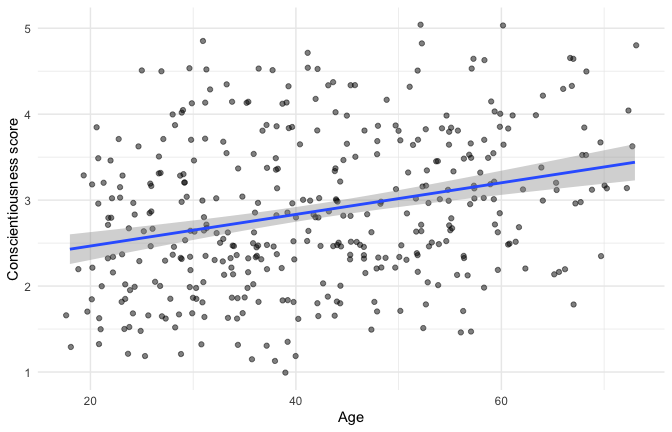

```r
tm |>
  activate(rows) |>
  as_tibble() |>
  ggplot(aes(age, score_Conscientiousness)) +
  geom_jitter(height = 0.05, alpha = 0.5) +
  geom_smooth(method = "lm", formula = y ~ x) +
  labs(x = "Age", y = "Conscientiousness score")
```

### Test results

Results of `compute_ttest()` and friends are tibbles with the item metadata included, so a volcano plot takes a few lines:

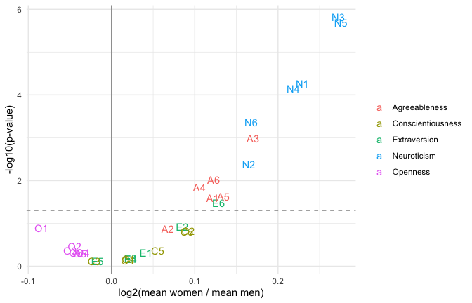

```r
tm |>
  activate(rows) |>
  filter(gender %in% c("Female", "Male")) |>
  activate(columns) |>
  compute_ttest(group_col = "gender", control = "Male", treatment = "Female") |>
  ggplot(aes(log2fc, -log10(p.value), colour = trait)) +
  geom_hline(yintercept = -log10(0.05), linetype = "dashed", colour = "grey60") +
  geom_vline(xintercept = 0, colour = "grey60") +
  geom_text(aes(label = item_id)) +
  labs(
    x = "log2(mean women / mean men)",
    y = "-log10(p-value)",
    colour = NULL
  )
```

## Plotting individual values with `to_long()`

`to_long()` converts the whole tidymatrix into a long table: one row per cell, with the row metadata, the column metadata and the `value`.

```r
long <- to_long(tm)
dim(long)
```

```
#> [1] 11640    24
```

```r
long |> select(respondent_id, gender, age_group, item_id, trait, value)
```

```
#> # A tibble: 11,640 × 6
#>    respondent_id gender age_group item_id trait        value
#>    <chr>         <chr>  <fct>     <chr>   <chr>        <int>
#>  1 R001          Female 50-64     E1      Extraversion     4
#>  2 R002          Female 30-49     E1      Extraversion     2
#>  3 R003          Male   65+       E1      Extraversion     2
#>  4 R004          Male   30-49     E1      Extraversion     2
#>  5 R005          Female 30-49     E1      Extraversion     1
#>  6 R006          Female 50-64     E1      Extraversion     1
#>  7 R007          Female 18-29     E1      Extraversion     3
#>  8 R008          Female 30-49     E1      Extraversion     2
#>  9 R009          Male   50-64     E1      Extraversion     4
#> 10 R010          Female 50-64     E1      Extraversion     4
#> # ℹ 11,630 more rows
```

If a column name occurs in both the row and the column metadata, all columns are prefixed with `row.` and `col.` to keep them apart.

From here, any ggplot is possible. The distribution of answers to the neuroticism items, by gender:

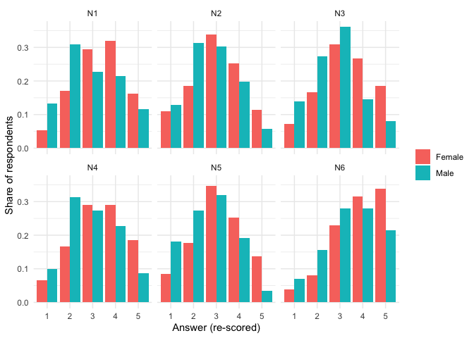

```r
long |>
  filter(trait == "Neuroticism", gender != "Non-binary") |>
  count(item_id, gender, value) |>
  group_by(item_id, gender) |>
  mutate(share = n / sum(n)) |>
  ggplot(aes(factor(value), share, fill = gender)) +
  geom_col(position = "dodge") +
  facet_wrap(~item_id) +
  labs(x = "Answer (re-scored)", y = "Share of respondents", fill = NULL)
```

Average answers per item and age group:

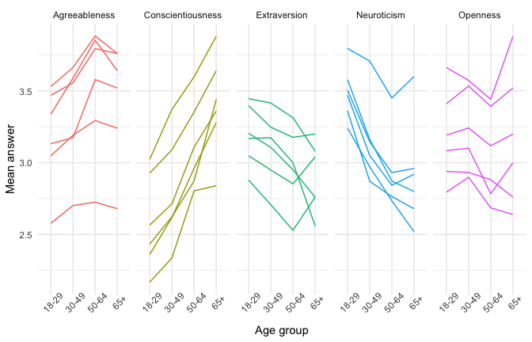

```r
long |>
  group_by(trait, item_id, age_group) |>
  summarise(mean = mean(value), .groups = "drop") |>
  ggplot(aes(age_group, mean, group = item_id, colour = trait)) +
  geom_line() +
  facet_wrap(~trait, nrow = 1) +
  labs(x = "Age group", y = "Mean answer") +
  theme(legend.position = "none", axis.text.x = element_text(angle = 45))
```

`to_long()` always converts the full matrix. Filter the tidymatrix first to keep the long table small.

## Heatmaps

`plot_pheatmap()` passes the matrix to `pheatmap::pheatmap()` and fills in the annotations and clusterings from the tidymatrix:

- `row_names` and `col_names` choose the metadata columns used as labels;
- `row_annotation` and `col_annotation` choose the metadata columns shown as colour bars (by default all of them, `FALSE` for none);
- if a stored `compute_hclust()` result exists for rows or columns, it is used to order them. `TRUE` lets pheatmap cluster, `FALSE` turns clustering off;
- all other arguments go to `pheatmap::pheatmap()`.

### Respondents × items

Standardising the items and clipping extreme values gives a readable colour scale. Clustering both dimensions with `compute_hclust()` makes the trait structure visible:

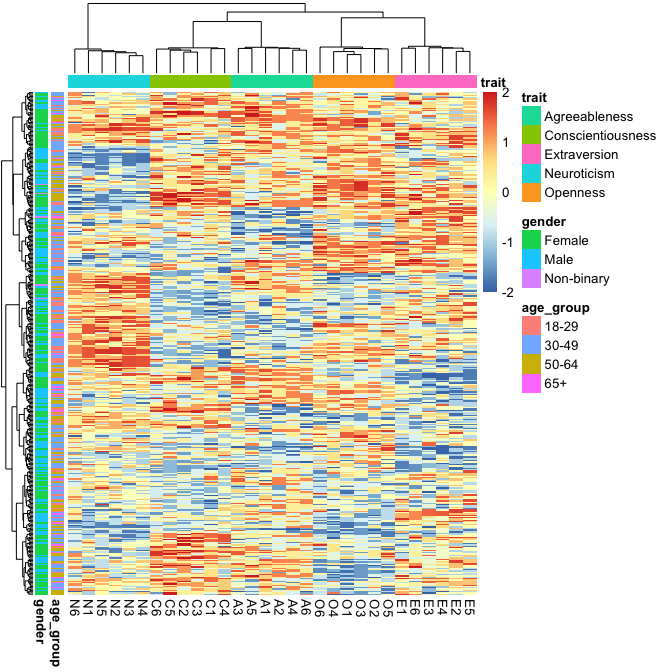

```r
tm |>
  activate(columns) |>
  scale() |>
  activate(matrix) |>
  clip_values(min = -2, max = 2) |>
  activate(columns) |>
  compute_hclust(method = "ward.D2") |>
  activate(rows) |>
  compute_hclust(method = "ward.D2") |>
  plot_pheatmap(
    col_names = "item_id",
    row_annotation = c("age_group", "gender"),
    col_annotation = "trait",
    show_rownames = FALSE,
    treeheight_row = 20
  )
```

### Aggregated heatmap

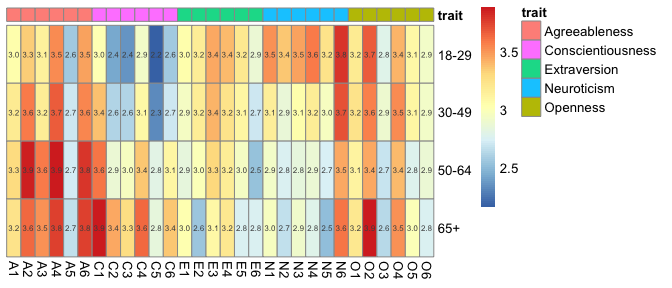

```r
tm |>
  activate(rows) |>
  group_by(age_group) |>
  summarise(n = n()) |>
  activate(columns) |>
  arrange(trait, item_id) |>
  plot_pheatmap(
    row_names = "age_group",
    col_names = "item_id",
    row_annotation = FALSE,
    col_annotation = "trait",
    row_cluster = FALSE,
    col_cluster = FALSE,
    display_numbers = TRUE,
    number_format = "%.1f",
    fontsize_number = 6
  )
```

## Exporting

### The matrix

`pull_active()` returns the active component. With the matrix active, that is a plain matrix:

```r
m <- tm |>
  activate(matrix) |>
  pull_active()

m[1:3, 1:6]
```

```
#>      E1 E2 E3 E4 E5 E6
#> R001  4  3  5  3  3  2
#> R002  2  4  2  2  3  2
#> R003  2  2  3  4  2  3
```

### The metadata

With rows or columns active, `pull_active()`, `as.data.frame()` and `as_tibble()` return the metadata, including anything added by analyses:

```r
tm |>
  activate(rows) |>
  as_tibble() |>
  select(respondent_id, starts_with("score_"), starts_with("row_pca"))
```

```
#> # A tibble: 388 × 8
#>    respondent_id score_Agreeableness score_Conscientiousness score_Extraversion
#>    <chr>                       <dbl>                   <dbl>              <dbl>
#>  1 R001                         3.33                    1.5                3.33
#>  2 R002                         2.83                    2.67               2.5
#>  3 R003                         3.33                    2.17               2.67
#>  4 R004                         2.83                    2.5                2.67
#>  5 R005                         4.83                    3.67               1.33
#>  6 R006                         4                       2.17               2.5
#>  7 R007                         4.83                    3.17               3
#>  8 R008                         3                       2.33               2.67
#>  9 R009                         4.5                     3.83               2.67
#> 10 R010                         3.67                    4.67               4.17
#> # ℹ 378 more rows
#> # ℹ 4 more variables: score_Neuroticism <dbl>, score_Openness <dbl>,
#> #   row_pca_PC1 <dbl>, row_pca_PC2 <dbl>
```

### Everything at once

`to_long()` is the most complete export: every value together with all its metadata, in a format that spreadsheets, databases and other tools understand.

```r
out <- tempfile(fileext = ".csv")

tm |>
  activate(columns) |>
  select(item_id, trait, item_text) |>
  activate(rows) |>
  select(respondent_id, age, gender, country) |>
  to_long() |>
  write.csv(out, row.names = FALSE)

read.csv(out, nrows = 3)
```

```
#>   respondent_id age gender country item_id        trait
#> 1          R001  52 Female      EE      E1 Extraversion
#> 2          R002  32 Female      FI      E1 Extraversion
#> 3          R003  66   Male      EE      E1 Extraversion
#>                           item_text value
#> 1 I feel comfortable around people.     4
#> 2 I feel comfortable around people.     2
#> 3 I feel comfortable around people.     2
```

The first two steps keep only the metadata columns that are needed; the matrix is not affected.

To save the tidymatrix itself, including stored analyses, use `saveRDS()` and `readRDS()`.

## See also

- PCA and clustering
- MDS, t-SNE and UMAP
- Row- and column-wise statistics